# Ohio 2012 Presidential Campaign Contributions by Christopher B. Winkelman

========================================================

# 1 Introduction

This project is an exploratory data analysis of campaign contributions for the 2012 presidential election in the state of Ohio. The state of Ohio is historically a critical swing state for presidential elections and, according to wikipedia, has the longest streak of matching the overall election outcome (since 1960). It would be a mistake to assume that campaign contributions are a predictor or even loosely correlated with votes (I might be biting my tongue if we were talking about superPACs though), but Ohio is one of the most frequently visited states on a presidential nominee’s campaign trail and for this reason it piqued my interest. I’ll explore the nature of campaign contributions and see if there are any interesting relationships in the data. I’ll also take a look at the geographic distribution of campaign contributions by zipcode. This exploration may shed light on the characteristics of a generous contributor and perhaps why particular party candidates visit certain areas in the state. Anything of significance could be used in future inferential or predictive analysis.

# 2 Load Data

There are 3 data sets here:

- campaign contribution data
- geographic data (to generate maps)
- demographic data (to add extra features)

We’ll link these datasets by zipcode much like tables in a database. The geographic and demographic data come from a library and are already nicely formatted. The features in the campaign contribution data, however, might need some explicit class declarations

Let’s peak at the first few rows to inspect the atomic classes (aka types).

```r
df_look <- read.csv("campaign-contributions-ohio-2012.csv", nrows = 100)
```

```
## Error in read.table(file = file, header = header, sep = sep, quote = quote, : duplicate 'row.names' are not allowed
```

While trying to read the file, we get some kind of error about the row names. Let’s explicitly set `row.names = NULL` to see if that fixes it.

```r
df_look <- read.csv("campaign-contributions-ohio-2012.csv", nrows = 100,
                    row.names=NULL)
```

```
##   row.names   cmte_id       cand_id              cand_nm    contbr_nm
## 1 C00495820 P80000748     Paul, Ron    BROWN, TODD W MR.      BATAVIA
## 2 C00495820 P80000748     Paul, Ron   DIEHL, MARGO SONJA       CANTON
## 3 C00495820 P80000748     Paul, Ron KIRCHMEYER, BENJAMIN NORTH CANTON
## 4 C00431445 P80003338 Obama, Barack       KEYES, STEPHEN       BEXLEY
## 5 C00431445 P80003338 Obama, Barack       MURPHY, MIKE W     COLUMBUS
## 6 C00431445 P80003338 Obama, Barack     ASHMAN, LEWIS J.       DAYTON
##   contbr_city contbr_st                      contbr_zip
## 1          OH 451034017                GENERAL ELECTRIC
## 2          OH     44718                            NONE
## 3          OH     44720                    DIEBOLD, INC
## 4          OH 432091491 NATIONWIDE MUTUAL INSURANCE CO.
## 5          OH     43214               ROCK TENN COMPANY
## 6          OH 454091226         KETTERING SCHOOL SYSTEM
##           contbr_employer contbr_occupation contb_receipt_amt
```

[output cut: 20 more lines]

By setting the row names to `NULL` we forced row numbering but for some reason it used an existing column as the row number. Using `head` to look at the first 6 lines, it seems like there is a mismatch between the header and the rest of the data. Let’s manually open a connection to the file and read a few lines including the header to see if we can pinpoint the problem.

```r
con <- file("campaign-contributions-ohio-2012.csv", "r")
lines <- readLines(con, 5); close(con); lines
```

```
## [1] "cmte_id,cand_id,cand_nm,contbr_nm,contbr_city,contbr_st,contbr_zip,contbr_employer,contbr_occupation,contb_receipt_amt,contb_receipt_dt,receipt_desc,memo_cd,memo_text,form_tp,file_num,tran_id,election_tp"
## [2] "C00495820,\"P80000748\",\"Paul, Ron\",\"BROWN, TODD W MR.\",\"BATAVIA\",\"OH\",\"451034017\",\"GENERAL ELECTRIC\",\"ENGINEER\",50,06-DEC-11,\"\",\"\",\"\",\"SA17A\",\"779227\",\"0925592\",\"P2012\","
## [3] "C00495820,\"P80000748\",\"Paul, Ron\",\"DIEHL, MARGO SONJA\",\"CANTON\",\"OH\",\"44718\",\"NONE\",\"RETIRED\",25,06-DEC-11,\"\",\"\",\"\",\"SA17A\",\"779227\",\"0925663\",\"P2012\","
## [4] "C00495820,\"P80000748\",\"Paul, Ron\",\"KIRCHMEYER, BENJAMIN\",\"NORTH CANTON\",\"OH\",\"44720\",\"DIEBOLD, INC\",\"COMPUTER PROGRAMMER\",201.2,06-DEC-11,\"\",\"\",\"\",\"SA17A\",\"779227\",\"0925696\",\"P2012\","
## [5] "C00431445,\"P80003338\",\"Obama, Barack\",\"KEYES, STEPHEN\",\"BEXLEY\",\"OH\",\"432091491\",\"NATIONWIDE MUTUAL INSURANCE CO.\",\"HR EXECUTIVE / ATTORNEY\",100,30-SEP-11,\"\",\"\",\"\",\"SA17A\",\"756218\",\"C12432798\",\"P2012\","
```

It’s difficult to tell from this output, but it looks like we have an extra empty column at the end of each row. We could use `count.fields()` but that opens up the entire file. Instead, let’s create a smaller test file to do this.

```r
con <- file("campaign-contributions-ohio-2012.csv", "r")
lines <- readLines(con, 20); close(con)

# using write.csv() here seems to cause problems with escape characters
# using a connection object works better
con <- file("test.csv"); writeLines(lines, con); close(con)
count.fields("test.csv", sep = ",")
```

```
##  [1] 18 19 19 19 19 19 19 19 19 19 19 19 19 19 19 19 19 19 19 19
```

This confirms that the data following the header somehow has an extra field. Looking back at the results from `head` and `readlines`, we can see that the extra field is full of NAs and it’s just an empty field caused by `","` at the end of each row.

We can fix this a few different ways. We can set the row names to NULL again, shift the column names to the left, and then remove the last column from the dataframe. Or, we can get the header row by itself and then use it as the column name for the rest of the data without that last empty column. The second options seems easier so we’ll go with that. After, we can finally peak into the correctly structured data to see if we need to make any adjustments (like strings as factors).

```
## 'data.frame':    19 obs. of  18 variables:
##  $ cmte_id          : Factor w/ 2 levels "C00431445","C00495820": 2 2 2 1 1 1 1 1 1 2 ...
##  $ cand_id          : Factor w/ 2 levels "P80000748","P80003338": 1 1 1 2 2 2 2 2 2 1 ...
##  $ cand_nm          : Factor w/ 2 levels "Obama, Barack",..: 2 2 2 1 1 1 1 1 1 2 ...
##  $ contbr_nm        : Factor w/ 19 levels "ASHMAN, LEWIS J.",..: 4 5 11 10 15 1 12 3 9 14 ...
##  $ contbr_city      : Factor w/ 17 levels "BATAVIA","BEXLEY",..: 1 3 10 2 6 7 5 4 14 8 ...
##  $ contbr_st        : Factor w/ 1 level "OH": 1 1 1 1 1 1 1 1 1 1 ...
##  $ contbr_zip       : int  451034017 44718 44720 432091491 43214 454091226 441201574 452243150 45690 440775592 ...
##  $ contbr_employer  : Factor w/ 17 levels "CH2M HILL","DIEBOLD, INC",..: 6 10 2 9 13 7 12 12 11 4 ...
##  $ contbr_occupation: Factor w/ 15 levels "BUSINESS OWNER",..: 3 11 2 4 6 15 10 11 14 12 ...
##  $ contb_receipt_amt: num  50 25 201 100 50 ...
##  $ contb_receipt_dt : Factor w/ 10 levels "04-AUG-11","06-DEC-11",..: 2 2 2 9 6 7 9 6 1 2 ...
##  $ receipt_desc     : logi  NA NA NA NA NA NA ...
##  $ memo_cd          : logi  NA NA NA NA NA NA ...
##  $ memo_text        : logi  NA NA NA NA NA NA ...
##  $ form_tp          : Factor w/ 1 level "SA17A": 1 1 1 1 1 1 1 1 1 1 ...
##  $ file_num         : int  779227 779227 779227 756218 756218 756218 756218 756218 756218 779227 ...
##  $ tran_id          : Factor w/ 19 levels "0922774","0922801",..: 6 7 8 18 14 16 19 15 10 1 ...
##  $ election_tp      : Factor w/ 1 level "P2012": 1 1 1 1 1 1 1 1 1 1 ...
```

There are more features that we want as factors than characters so we’ll keep that default setting. Contributor name should be a character, and zipcode should also be a character since it looks like some zipcodes are the full 9 digits and thus we’re gonna have to do some string manipulation. The receipt date should be a date object but we can also set that manually after we read in the data.

Now we can read in the entire contributions file. We’ll have to skip the header again but since we already have the column names from the test dataframe we can set them easily. We add a dummy name to the column names variable to account for the empty entry and then delete that column afterwards.

```r
column_names <- c(column_names, "dummy")
df <- read.csv("campaign-contributions-ohio-2012.csv",
                     header = FALSE, col.names = column_names, skip = 1)
df$dummy <- NULL; head(df)
```

```
##     cmte_id   cand_id       cand_nm            contbr_nm  contbr_city
## 1 C00495820 P80000748     Paul, Ron    BROWN, TODD W MR.      BATAVIA
## 2 C00495820 P80000748     Paul, Ron   DIEHL, MARGO SONJA       CANTON
## 3 C00495820 P80000748     Paul, Ron KIRCHMEYER, BENJAMIN NORTH CANTON
## 4 C00431445 P80003338 Obama, Barack       KEYES, STEPHEN       BEXLEY
## 5 C00431445 P80003338 Obama, Barack       MURPHY, MIKE W     COLUMBUS
## 6 C00431445 P80003338 Obama, Barack     ASHMAN, LEWIS J.       DAYTON
##   contbr_st contbr_zip                 contbr_employer
## 1        OH  451034017                GENERAL ELECTRIC
## 2        OH      44718                            NONE
## 3        OH      44720                    DIEBOLD, INC
## 4        OH  432091491 NATIONWIDE MUTUAL INSURANCE CO.
## 5        OH      43214               ROCK TENN COMPANY
## 6        OH  454091226         KETTERING SCHOOL SYSTEM
##         contbr_occupation contb_receipt_amt contb_receipt_dt receipt_desc
## 1                ENGINEER              50.0        06-DEC-11
## 2                 RETIRED              25.0        06-DEC-11
## 3     COMPUTER PROGRAMMER             201.2        06-DEC-11
## 4 HR EXECUTIVE / ATTORNEY             100.0        30-SEP-11
## 5                 MANAGER              50.0        26-SEP-11
## 6                 TEACHER              50.0        27-SEP-11
##   memo_cd memo_text form_tp file_num   tran_id election_tp
## 1                     SA17A   779227   0925592       P2012
## 2                     SA17A   779227   0925663       P2012
## 3                     SA17A   779227   0925696       P2012
## 4                     SA17A   756218 C12432798       P2012
## 5                     SA17A   756218 C12223508       P2012
## 6                     SA17A   756218 C12234248       P2012
```

I’m curious to see how the `readr` package might have handled this, as it’s supposed to be more intuitive with reading flat files. The only drawback is that we would have to set the factors manually which could be pretty lengthy. In any case, let’s check it out.

```r
df_readr <- read_csv("campaign-contributions-ohio-2012.csv",
                     n_max = 100)
```

```
## Warning: 101 parsing failures.
## row col   expected     actual
##   1  -- 18 columns 19 columns
##   2  -- 18 columns 19 columns
##   3  -- 18 columns 19 columns
##   4  -- 18 columns 19 columns
##   5  -- 18 columns 19 columns
## ... ... .......... ..........
## .See problems(...) for more details.
```

```
## Classes 'tbl_df', 'tbl' and 'data.frame':    100 obs. of  18 variables:
##  $ cmte_id          : chr  "C00495820" "C00495820" "C00495820" "C00431445" ...
##  $ cand_id          : chr  "P80000748" "P80000748" "P80000748" "P80003338" ...
##  $ cand_nm          : chr  "Paul, Ron" "Paul, Ron" "Paul, Ron" "Obama, Barack" ...
##  $ contbr_nm        : chr  "BROWN, TODD W MR." "DIEHL, MARGO SONJA" "KIRCHMEYER, BENJAMIN" "KEYES, STEPHEN" ...
##  $ contbr_city      : chr  "BATAVIA" "CANTON" "NORTH CANTON" "BEXLEY" ...
##  $ contbr_st        : chr  "OH" "OH" "OH" "OH" ...
##  $ contbr_zip       : int  451034017 44718 44720 432091491 43214 454091226 441201574 452243150 45690 440775592 ...
##  $ contbr_employer  : chr  "GENERAL ELECTRIC" "NONE" "DIEBOLD, INC" "NATIONWIDE MUTUAL INSURANCE CO." ...
##  $ contbr_occupation: chr  "ENGINEER" "RETIRED" "COMPUTER PROGRAMMER" "HR EXECUTIVE / ATTORNEY" ...
##  $ contb_receipt_amt: num  50 25 201 100 50 ...
##  $ contb_receipt_dt : chr  "06-DEC-11" "06-DEC-11" "06-DEC-11" "30-SEP-11" ...
##  $ receipt_desc     : chr  "" "" "" "" ...
##  $ memo_cd          : chr  "" "" "" "" ...
##  $ memo_text        : chr  "" "" "" "" ...
##  $ form_tp          : chr  "SA17A" "SA17A" "SA17A" "SA17A" ...
##  $ file_num         : int  779227 779227 779227 756218 756218 756218 756218 756218 756218 779227 ...
##  $ tran_id          : chr  "0925592" "0925663" "0925696" "C12432798" ...
##  $ election_tp      : chr  "P2012" "P2012" "P2012" "P2012" ...
##  - attr(*, "problems")=Classes 'tbl_df', 'tbl' and 'data.frame': 101 obs. of  4 variables:
##   ..$ row     : int  1 2 3 4 5 6 7 8 9 10 ...
##   ..$ col     : chr  NA NA NA NA ...
##   ..$ expected: chr  "18 columns" "18 columns" "18 columns" "18 columns" ...
##   ..$ actual  : chr  "19 columns" "19 columns" "19 columns" "19 columns" ...
```

We got a warning about the column mismatch but `readr` handled the discrepancy. We could have done this instead and set the factors one by one but `read.csv` allows us to set all characters as factors which was advantageous. It took way more effort than `readr` would have, but it also allowed us to pinpoint the exact problem.

Back to loading the rest of the data. Let’s load the geographic and demographic data.

```
## 'data.frame':    5403044 obs. of  13 variables:
##  $ long      : num  -88.4 -88.4 -88.4 -88.4 -88.4 ...
##  $ lat       : num  31.1 31.1 31.1 31.1 31.1 ...
##  $ order     : int  1 2 3 4 5 6 7 8 9 10 ...
##  $ hole      : logi  FALSE FALSE FALSE FALSE FALSE FALSE ...
##  $ piece     : Factor w/ 21 levels "1","2","3","4",..: 1 1 1 1 1 1 1 1 1 1 ...
##  $ group     : Factor w/ 42275 levels "0.1","1.1","1.2",..: 1 1 1 1 1 1 1 1 1 1 ...
##  $ id        : chr  "0" "0" "0" "0" ...
##  $ ZCTA5CE10 : Factor w/ 32989 levels "01001","01002",..: 11619 11619 11619 11619 11619 11619 11619 11619 11619 11619 ...
##  $ AFFGEOID10: Factor w/ 32989 levels "8600000US01001",..: 11619 11619 11619 11619 11619 11619 11619 11619 11619 11619 ...
##  $ GEOID10   : Factor w/ 32989 levels "01001","01002",..: 11619 11619 11619 11619 11619 11619 11619 11619 11619 11619 ...
##  $ ALAND10   : num  5.7e+08 5.7e+08 5.7e+08 5.7e+08 5.7e+08 ...
##  $ AWATER10  : num  3241962 3241962 3241962 3241962 3241962 ...
##  $ region    : chr  "36522" "36522" "36522" "36522" ...
```

```
## 'data.frame':    33120 obs. of  9 variables:
##  $ region           : chr  "00601" "00602" "00603" "00606" ...
##  $ total_population : num  18450 41302 53683 6591 28963 ...
##  $ percent_white    : num  1 4 2 0 1 0 0 1 2 0 ...
##  $ percent_black    : num  0 0 0 0 0 0 0 0 0 0 ...
##  $ percent_asian    : num  0 0 0 0 0 0 0 0 0 0 ...
##  $ percent_hispanic : num  99 94 96 100 99 100 100 99 98 100 ...
##  $ per_capita_income: num  7380 8463 9176 6383 7892 ...
##  $ median_rent      : num  285 319 252 230 334 315 285 338 400 319 ...
##  $ median_age       : num  36.6 38.6 38.9 37.3 39.2 38.5 40.9 36.2 42 39.7 ...
```

For both of these dataframes, the `region` variable (zipcode) is what we’ll be using to relate to the contributions data. For the demographic data, we can add the fields we want to the contributions dataframe. However, we’ll be making choropleth maps with the geographic data from different aggregate statistics from the contributions dataframe. So we’ll have to concatenate these 2 on the fly depending upon what we want to show.

# 3 Data Manipulation

Before adding the demographic data, let’s get the contributions dataframe prepared. Let’s get rid of the data we don’t want and rename the columns. There are quite a few features in the contribution data that don’t really help our exploration like the ID number of the candidate or the file number of the contribution. The only features of interest are `candidate`, `name` (of the contributor), `city`, `state`, `zipcode`, `employer`, `occupation`, `amount`, and `date`.

```r
df <- df[, 3:11] # the features we want are consecutive
# rename the features to make them more readable
names(df) <- c("candidate", "name", "city", "state", "zipcode",
                 "employer", "occupation", "amount", "date")
summary(df)
```

```
##           candidate                        name                city
##  Obama, Barack :91286   WADE, ANNIE SANDS    :   114   CINCINNATI: 18596
##  Romney, Mitt  :50672   DUPHIL, MONIQUE      :    99   COLUMBUS  : 13820
##  Paul, Ron     : 4271   RINGO, RICHARD A. MR.:    97   DAYTON    :  5536
##  Santorum, Rick: 2012   POWERS, KAREN        :    90   CLEVELAND :  4748
##  Gingrich, Newt: 1432   KNEELAND, HAROLD     :    88   TOLEDO    :  3276
##  Cain, Herman  :  583   RUPPER, DARVIS       :    86   AKRON     :  2965
##  (Other)       : 1223   (Other)              :150905   (Other)   :102538
##  state          zipcode
##  OH:151479   43214  :   655
##              44122  :   586
##              44118  :   584
##              43202  :   511
##              44107  :   507
##              45220  :   476
##              (Other):148160
##                                    employer
##  RETIRED                               :34269
##  SELF-EMPLOYED                         :11503
##  NOT EMPLOYED                          : 8657
##  INFORMATION REQUESTED PER BEST EFFORTS: 6049
##  INFORMATION REQUESTED                 : 4217
##  (Other)                               :86741
##  NA's                                  :   43
##                                   occupation        amount
##  RETIRED                               :38151   Min.   :-15000.0
##  INFORMATION REQUESTED PER BEST EFFORTS: 5778   1st Qu.:    25.0
##  HOMEMAKER                             : 4674   Median :    50.0
##  PHYSICIAN                             : 4458   Mean   :   202.5
##  ATTORNEY                              : 4056   3rd Qu.:   150.0
##  (Other)                               :94351   Max.   : 10000.0
##  NA's                                  :   11
##         date
##  17-OCT-12:  4176
##  02-NOV-12:  3465
##  23-OCT-12:  3066
##  22-OCT-12:  2569
##  31-OCT-12:  2547
##  31-AUG-12:  2534
##  (Other)  :133122
```

There’s something interesting here that we can see by leaving the contributor names as factors. There are a few contributors who made nearly 100 contributions. We can also see which zipcodes had the most contributions. This information could definitely be worth exploring later but we’ll need these features as characters for now.

Let’s coerce those features that we mentioned before to characters and make date into a date object.

```r
to_character <- c("name", "zipcode", "date")

for(col in to_character) {
    df[, col] <- as.character(df[, col])
}

df$date <- as.Date(df$date, format = "%d-%b-%y"); sapply(df, class)
```

```
##   candidate        name        city       state     zipcode    employer
##    "factor" "character"    "factor"    "factor" "character"    "factor"
##  occupation      amount        date
##    "factor"   "numeric"      "Date"
```

Now let’s clean the zipcodes so that they all have just 5 digits, and so that we can relate them to the zipcodes in the geographic and demographic data. We also have to make sure that they are in Ohio.

```r
df$zipcode <- substring(df$zipcode, 1, 5)
# if starts with '45' or '44' or '43' then in Ohio
zip_legit <- as.character(seq(43000, 46000, by = 1))
# convert non-legit zipcodes to 'NA' character
df$zipcode <- ifelse(df$zipcode %in% zip_legit, df$zipcode, 'NA')
summary(as.numeric(df$zipcode))
```

```
##    Min. 1st Qu.  Median    Mean 3rd Qu.    Max.    NA's
##   43000   43550   44150   44320   45210   45900     219
```

Looks like they are all within the correct range with the exception of the NAs. This data won’t be usable for the choropleth maps but it’s still useful for other statistics so we’ll keep it.

We do have negative amounts though, which happen to be refunds, so we’ll have to exclude those observations.

```r
bad <- df$amount <= 0; sum(bad); df <- df[!bad, ]
```

```
## [1] 1272
```

There were 1272 refunds excluded.

Let’s engineer some features in order to make more use of the data that we have. We’ll get gender from name and party status from candidate.

```r
# make first name feature from full name
df$first_name <- substring(str_extract(df$name, ',\\s[A-Z]+'), 3, )
# get dataframe of unique first names and gender
gender_names_df <- gender(unique(df$first_name)) %>% select(name, gender)

# merge dataframe with gender names
df <- merge(df, gender_names_df,
            by.x = 'first_name', by.y = 'name', all.x = TRUE)

# get rid of first name and gender names df, make gender a factor
df$first_name <- NULL; rm(gender_names_df); df$gender <- as.factor(df$gender)
# NA gender count
print("missing gender:"); sum(is.na(df$gender))
```

```
## [1] "missing gender:"
```

```
## [1] 4677
```

```r
candidates <- unique(df$candidate)
democrat <- "Obama, Barack"; green <- "Stein, Jill"
republican <- candidates[!(candidates %in% c(democrat, green))]
df$party <- ifelse(df$candidate %in% republican, "republican",
                   ifelse(df$candidate == democrat, "democrat", "green"))
df$party <- as.factor(df$party)
```

Now we can add demographic data to the dataset and get coordinates for the cities from the web. The cities will help us to see things better on the map.

```r
demographics.ohio <- df_zip_demographics %>% filter(region %in% zip_legit)
df <- merge(df, demographics.ohio,
            by.x = 'zipcode', by.y = 'region', all.x = TRUE)
# shorten the names
colnames(df)[12:19] <- c("population", "pcnt_wht", "pcnt_blk", "pcnt_asn",
                         "pcnt_hsp", "percap_incm", "med_rent", "med_age")
rm(df_zip_demographics)

# get city coordinates
webpage_ohio_cities <-
  read_html("http://www.geonames.org/US/OH/largest-cities-in-ohio.html")
city_names <- webpage_ohio_cities %>%
  xml_find_all("//tr/td/a[contains(@href, 'geonames')]/text()") %>%
  as.character()
city_pop <- webpage_ohio_cities %>%
  xml_find_all("//tr/td[contains(@class, 'rightalign')]/text()") %>%
  as.character() %>%
  sub(",", "", .) %>%
  as.numeric()
city_coord <- webpage_ohio_cities %>%
  xml_find_all('//tr/td/a[contains(@href, "maps")]/text()') %>%
  as.character()
city_lat <- as.numeric(str_extract(city_coord, '^[0-9.]+'))
city_long <- as.numeric(str_extract(city_coord, '[-0-9.]+$'))
mapdata.ohio.cities <- data.frame(city_names, city_long, city_lat, city_pop)
```

Finally, we will subset the map data for Ohio only, since it includes the entire United States.

```r
mapdata.ohio <- zip.map %>% filter(region %in% zip_legit) %>% arrange(order)
rm(zip.map)
# save/load data into .Rdata file for easy start
#save(df, demographics.ohio, mapdata.ohio, mapdata.ohio.cities, file = "processed-data.Rdata")
#load("processed-data.Rdata")
```

# 4 Univariate Plots Section

```r
knitr::opts_chunk$set(echo=FALSE, warning=FALSE, messages=FALSE)
```

Now that the data is in the right format let’s start our univariate exploration.

```
##  [1] "zipcode"     "candidate"   "name"        "city"        "state"
##  [6] "employer"    "occupation"  "amount"      "date"        "gender"
## [11] "party"       "population"  "pcnt_wht"    "pcnt_blk"    "pcnt_asn"
## [16] "pcnt_hsp"    "percap_incm" "med_rent"    "med_age"
```

We have 19 different variables,

```
## 'data.frame':    150207 obs. of  19 variables:
##  $ zipcode    : chr  "43001" "43001" "43001" "43001" ...
##  $ candidate  : Factor w/ 14 levels "Bachmann, Michele",..: 12 7 12 12 12 12 12 12 12 12 ...
##  $ name       : chr  "CHAULK, SARAH" "BAKER, NANCY" "TODD, DARRELL M. MR." "CHAULK, JOSEPH MR." ...
##  $ city       : Factor w/ 1167 levels "ABERDEEN","ADA",..: 8 8 8 8 8 8 8 8 8 8 ...
##  $ state      : Factor w/ 1 level "OH": 1 1 1 1 1 1 1 1 1 1 ...
##  $ employer   : Factor w/ 13507 levels "","1099","121 ARW",..: 10417 994 5647 1634 5647 9804 2692 1634 1634 1634 ...
##  $ occupation : Factor w/ 6846 levels "","-","100% DISABLED VIETNAM VETERAN",..: 2594 4148 2960 882 2960 5231 1282 882 882 882 ...
##  $ amount     : num  546 35 100 92.2 125 ...
##  $ date       : Date, format: "2012-10-27" "2012-06-25" ...
##  $ gender     : Factor w/ 2 levels "female","male": 1 1 2 2 2 2 2 2 2 2 ...
##  $ party      : Factor w/ 3 levels "democrat","green",..: 3 1 3 3 3 3 3 3 3 3 ...
##  $ population : num  2295 2295 2295 2295 2295 ...
##  $ pcnt_wht   : num  93 93 93 93 93 93 93 93 93 93 ...
##  $ pcnt_blk   : num  0 0 0 0 0 0 0 0 0 0 ...
##  $ pcnt_asn   : num  0 0 0 0 0 0 0 0 0 0 ...
##  $ pcnt_hsp   : num  3 3 3 3 3 3 3 3 3 3 ...
##  $ percap_incm: num  34306 34306 34306 34306 34306 ...
##  $ med_rent   : num  592 592 592 592 592 592 592 592 592 592 ...
##  $ med_age    : num  46.2 46.2 46.2 46.2 46.2 46.2 46.2 46.2 46.2 46.2 ...
```

with varying classes.

```
##    zipcode                   candidate         name
##  Length:150207      Obama, Barack :90588   Length:150207
##  Class :character   Romney, Mitt  :50198   Class :character
##  Mode  :character   Paul, Ron     : 4246   Mode  :character
##                     Santorum, Rick: 2001
##                     Gingrich, Newt: 1391
##                     Cain, Herman  :  581
##                     (Other)       : 1202
##          city        state
##  CINCINNATI: 18446   OH:150207
##  COLUMBUS  : 13703
##  DAYTON    :  5488
##  CLEVELAND :  4697
##  TOLEDO    :  3261
##  AKRON     :  2940
##  (Other)   :101672
##                                    employer
##  RETIRED                               :34158
##  SELF-EMPLOYED                         :11477
##  NOT EMPLOYED                          : 8648
##  INFORMATION REQUESTED PER BEST EFFORTS: 6030
##  INFORMATION REQUESTED                 : 4216
##  (Other)                               :85635
##  NA's                                  :   43
##                                   occupation        amount
##  RETIRED                               :38029   Min.   :    1.0
##  INFORMATION REQUESTED PER BEST EFFORTS: 5759   1st Qu.:   25.0
##  HOMEMAKER                             : 4623   Median :   50.0
##  PHYSICIAN                             : 4447   Mean   :  210.8
##  ATTORNEY                              : 4033   3rd Qu.:  150.0
##  (Other)                               :93305   Max.   :10000.0
##  NA's                                  :   11
##       date               gender             party         population
##  Min.   :2011-01-28   female:66613   democrat  :90588   Min.   :    0
##  1st Qu.:2012-07-05   male  :78917   green     :   19   1st Qu.:16076
##  Median :2012-09-17   NA's  : 4677   republican:59600   Median :25049
##  Mean   :2012-08-05                                     Mean   :26621
##  3rd Qu.:2012-10-17                                     3rd Qu.:35078
##  Max.   :2012-12-27                                     Max.   :68475
##                                                         NA's   :973
##     pcnt_wht         pcnt_blk        pcnt_asn         pcnt_hsp
##  Min.   :  0.00   Min.   : 0.00   Min.   : 0.000   Min.   : 0.000
##  1st Qu.: 76.00   1st Qu.: 2.00   1st Qu.: 1.000   1st Qu.: 1.000
##  Median : 87.00   Median : 4.00   Median : 2.000   Median : 2.000
##  Mean   : 79.75   Mean   :12.22   Mean   : 2.936   Mean   : 2.842
##  3rd Qu.: 93.00   3rd Qu.:13.00   3rd Qu.: 4.000   3rd Qu.: 3.000
##  Max.   :100.00   Max.   :94.00   Max.   :22.000   Max.   :61.000
##  NA's   :987      NA's   :987     NA's   :987      NA's   :987
##   percap_incm       med_rent         med_age
##  Min.   :  864   Min.   : 213.0   Min.   : 6.80
##  1st Qu.:23951   1st Qu.: 550.0   1st Qu.:36.30
##  Median :30291   Median : 643.0   Median :39.50
##  Mean   :32167   Mean   : 668.4   Mean   :39.25
##  3rd Qu.:38759   3rd Qu.: 749.0   3rd Qu.:43.10
##  Max.   :67742   Max.   :1475.0   Max.   :83.50
##  NA's   :1023    NA's   :1735     NA's   :992
```

The most popular candidate to receive contributions was Barack Obama and the most popular party was the democratic party. The city with the most contributions was Cincinnati and retired people represented the occupation with the largest amount of contributions. The demographic of males made more contributions than females. The median contribution was $50 and the average is $211.

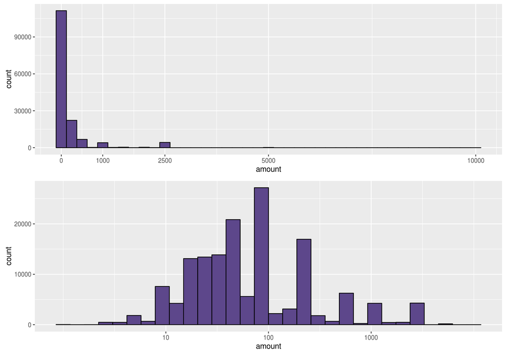

We have long-tailed data for the amount of contributions. There are so many contributions made under $1,000 that it’s hard to see any of the outliers. A logarithmic transformation of the x-axis reveals something of a log-normal distribution for the amount.

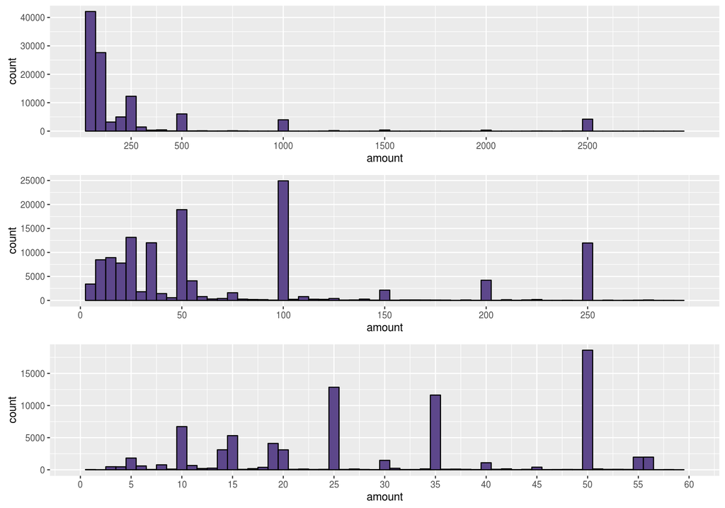

There are a significant group of people (4195) that, despite the long-tailed distribution, contribute $2,500. It may be that there is a tax write-off reason for this. Looking closer we can see that there appear to be several discrete values in increments of $50 that people are accustomed to contributing. Under $60, we can see contributions spaced in intervals of $5.

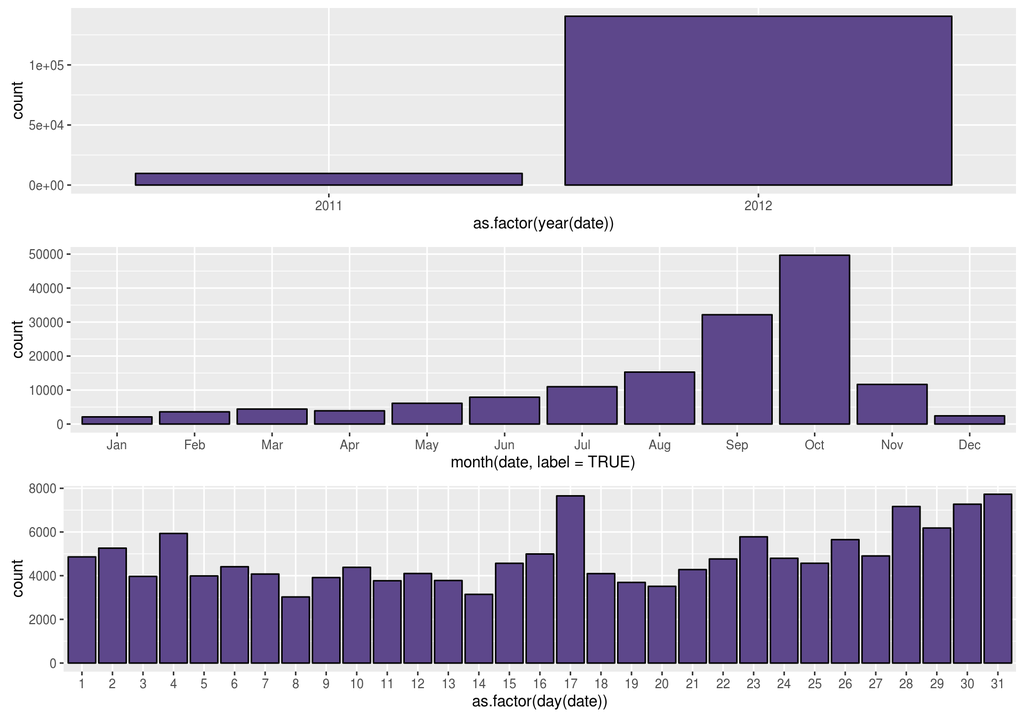

An overwhelming majority of contributions (93.5%) were made in 2012, and we can see a steady increase in contributions leading up to the election in November. There seems to be a slight increase in the amount of contributions made toward the end of the month. There is also a peak at about halfway through the month. People might be making contributions immediately after receiving their paychecks or pensions.

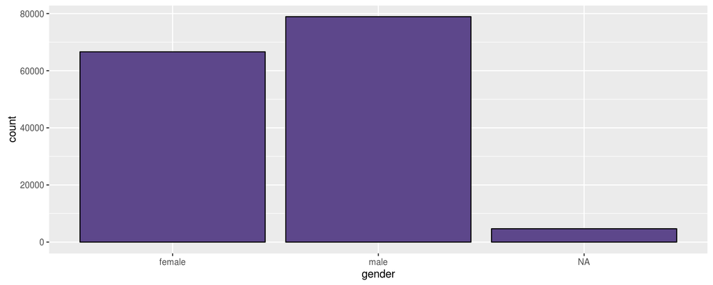

Although a significant difference between the amount of male and female contributions, the proportion (0.54 in favor of males) of the gap is not very large.

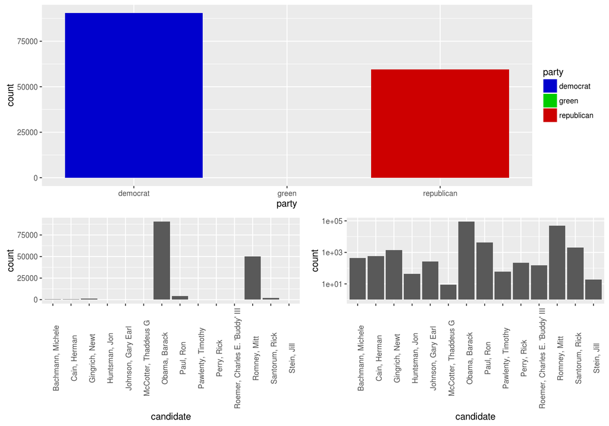

Most contributions are made to either Obama or Romney. Using a log scale we can see the other candidates a little better. Cumulatively, there are a significant amount of contributions made to other candidates but they are mostly Republican. The proportion of contributions to democrats vs. republicans seems to resemble the previous histrogram between Obama and Romney. The amount of contributions to the green party is so small (19 contributions) that we might want to exclude for simplicity.

It’s important to remember that the remaining demographic variables correspond to the contributor’s zipcode and not to the contributor him/herself.

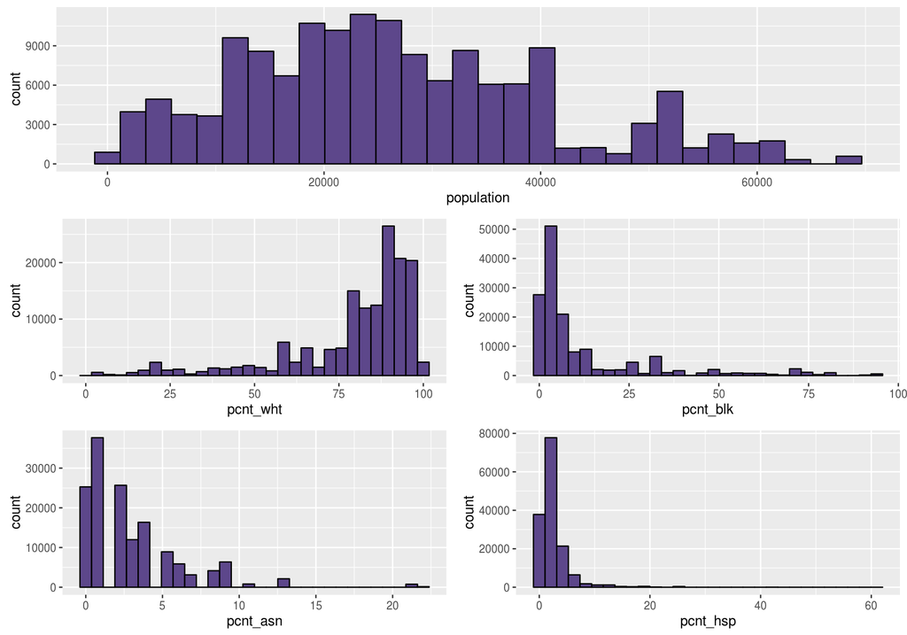

Most contributors live in areas with a high percentage of white ethnicity and low percentages of black, asian, or hispanic ethnicities.

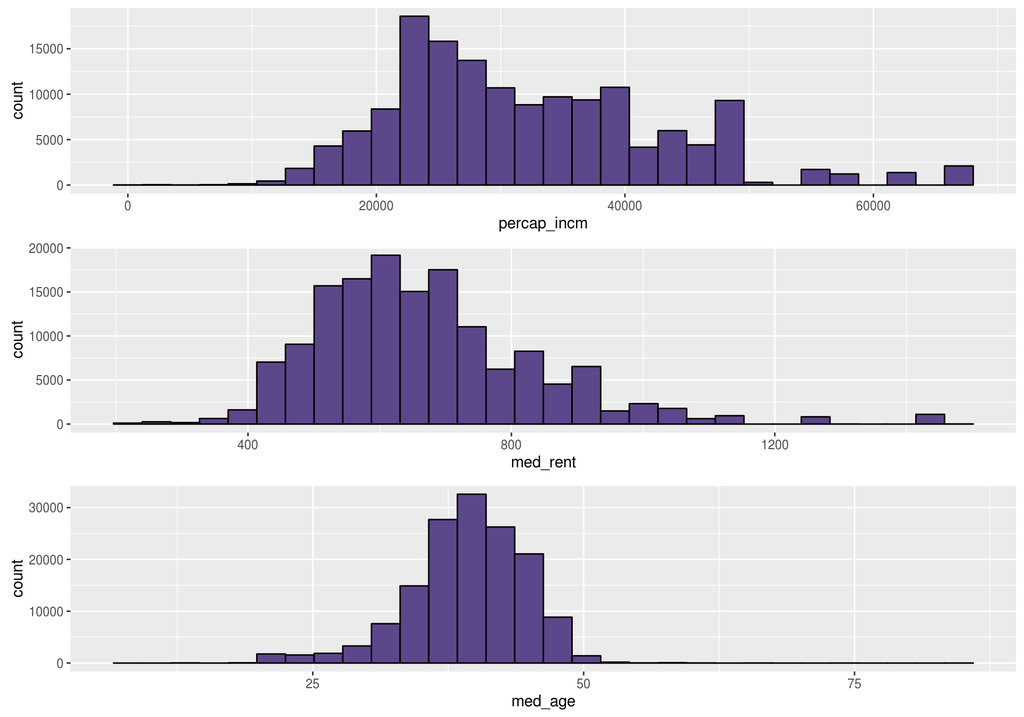

We see a fairly normal distribution with median rent in the locations in which contributors live. Rent is very cheap (median of $643) as compared to California but per capita income is also lower.

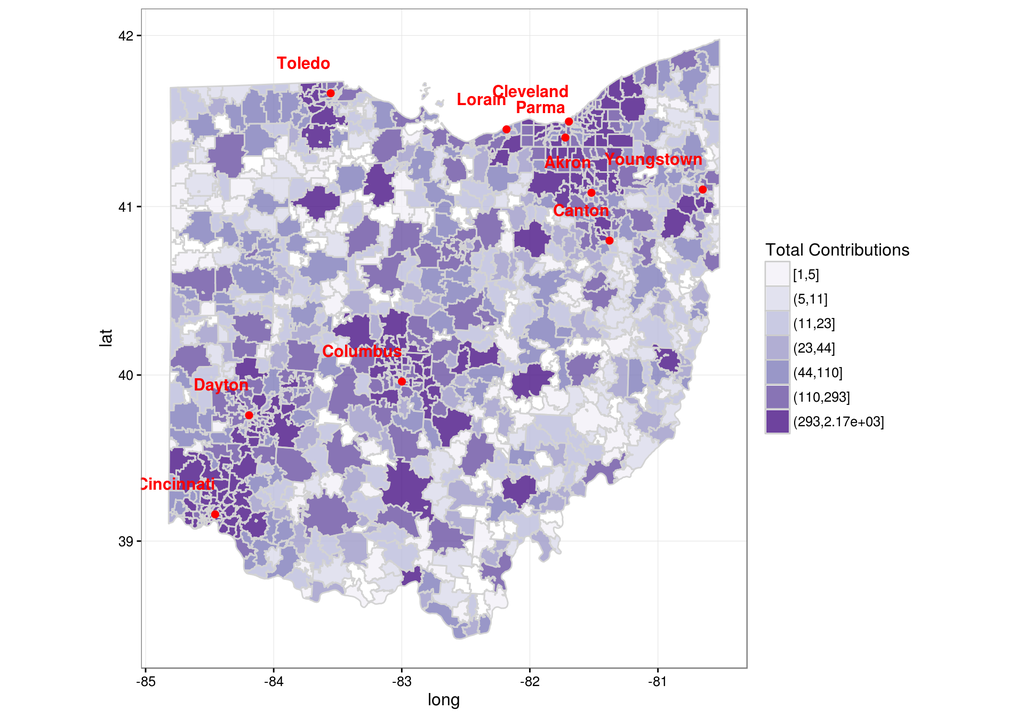

A choropleth map of total contributions by zipcode shows that contributions generally come from areas nearer to cities. There are also quite a few zipcodes without any contributions (seen with the same background color).

# 5 Univariate Analysis

### 5.0.1 What is the structure of your dataset?

- candidate
- name (contributor)
- city
- state
- zipcode
- employer
- occupation
- amount
- date
- gender
- party

Using the zipcode feature, demographic information was added from another data set:

- total_population
- percent_white
- percent_black
- percent_asian
- percent_hispanic
- per_capita_income
- median_rent
- median_age

### 5.0.2 What is/are the main feature(s) of interest in your dataset?

The main features of interest in the data set are amount, gender, party, per capita income, and median age. I would like to see if these factors are correlated with contribution amount. Occupation could be of interest however there are too many levels (6,846).

### 5.0.3 What other features in the dataset do you think will help support your investigation into your feature(s) of interest?

I believe that the percent ethnicities, total population, and median rent may be correlated with contribution amount.